# make-up-assignment

2023-12-04

Due at 9am on Dec 7.

## Frogs. Where are they and in what amount?

The National Science Foundation, being as invested in questions of basic science as they are, unilaterally funds research about frogs and where they’re located. Our work (as described in our generously awarded NSF proposal) requires that we count the number of frogs we observe as the distance between ourselves and the pond shore increases. Ultimately two things were recorded: **no. of frogs** and **distance from pond** (in meters).

Incredibly, and defying all known laws of nature, we observed that the number of total frogs observed **decreased** as we traveled further and further away (0-100m) from the pond.

Data collection was limited by worsening black bear attacks. We lost one (1) team member.

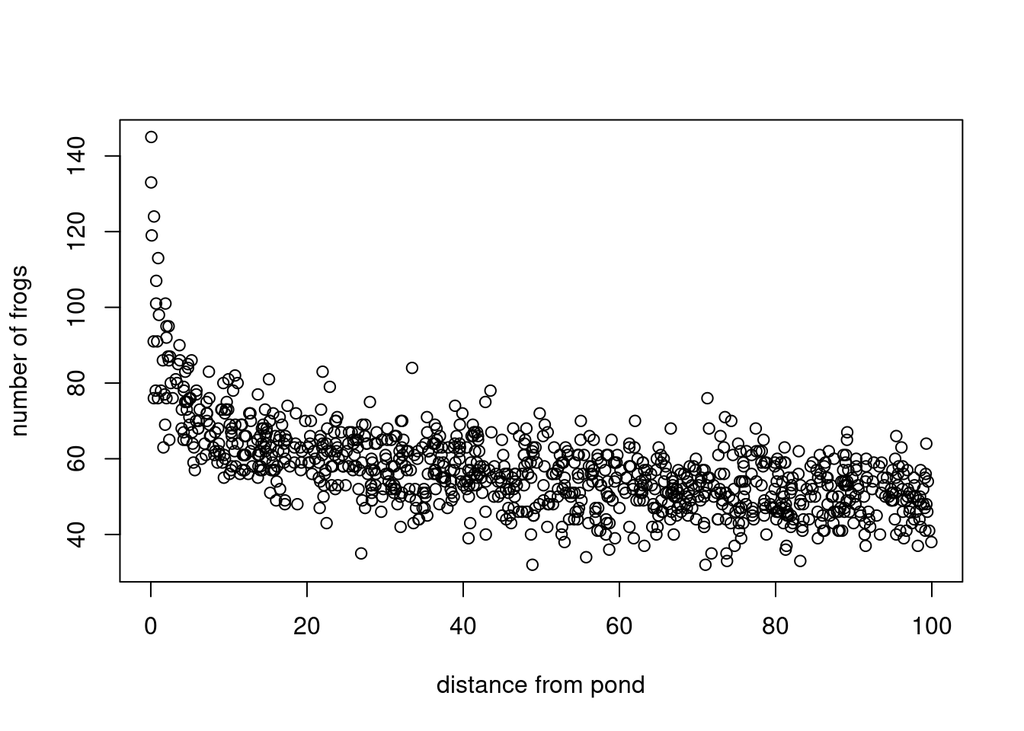

```r
myData <- read.csv('frogs.csv')

plot(myData$predictor, myData$response, xlab = "distance from pond", ylab = "number of frogs")
```

## Assignment

Use a generalized linear model to analyze the data described above to infer how the predictor (distance from pond) affects the number of frogs.

Please answer the following questions:

1. What is the deterministic function for your model?
2. What is the distribution and the inverse link equation that you used in your model?
3. What parameters are included in your model?
4. What is your best estimate of those parameters?